# HW6

葛宇泽 19307130176

2021/11/18

### 1. 读入数据并了解各个自变量的含义

```r
setwd("F:/2021秋季/机器学习/HW6")
data = read.csv("simudata.csv",sep=",",fileEncoding = 'UTF-8',head=T)
data$black = factor(data$black)
summary(data)
```

```
##      creded           debitF          meanpay           billnum
##  Min.   :0.0000   Min.   :  0.00   Min.   :      0   Min.   :  0.00
##  1st Qu.:0.0200   1st Qu.:  5.00   1st Qu.:  50475   1st Qu.: 11.00
##  Median :0.1000   Median : 25.00   Median : 231277   Median : 55.00
##  Mean   :0.1448   Mean   : 35.46   Mean   : 271800   Mean   : 74.47
##  3rd Qu.:0.2400   3rd Qu.: 57.00   3rd Qu.: 425342   3rd Qu.:119.00
##  Max.   :0.8200   Max.   :202.00   Max.   :1346594   Max.   :427.00
##      debitM          zhongxingM          sidaM            xindaiR
##  Min.   :     26   Min.   :      3   Min.   :     10   Min.   :  0.02
##  1st Qu.:  59310   1st Qu.:  21617   1st Qu.:  44692   1st Qu.: 70.17
##  Median : 264838   Median :  97913   Median : 219769   Median :155.52
##  Mean   : 305073   Mean   : 161771   Mean   : 271535   Mean   :163.34
##  3rd Qu.: 479646   3rd Qu.: 261094   3rd Qu.: 433841   3rd Qu.:241.02
##  Max.   :1436086   Max.   :1017770   Max.   :1299826   Max.   :365.00
##     cardnum          xindaiF          maxpay         zhuanzhangF
##  Min.   : 0.000   Min.   : 0.00   Min.   :      9   Min.   :  0.00
##  1st Qu.: 3.000   1st Qu.: 1.00   1st Qu.: 277166   1st Qu.:  3.00
##  Median : 6.000   Median : 4.00   Median :1182465   Median : 14.00
##  Mean   : 6.395   Mean   : 4.16   Mean   :1370679   Mean   : 22.19
##  3rd Qu.: 9.000   3rd Qu.: 7.00   3rd Qu.:2138145   3rd Qu.: 36.00
##  Max.   :26.000   Max.   :20.00   Max.   :6470316   Max.   :124.00
##    gongjiaoF       zhuanzhangR          age          gongjiaoR
##  Min.   :0.0000   Min.   :  0.28   Min.   :14.00   Min.   :206.3
##  1st Qu.:0.0000   1st Qu.:126.08   1st Qu.:27.00   1st Qu.:332.8
##  Median :0.0000   Median :219.46   Median :30.00   Median :359.5
##  Mean   :0.9369   Mean   :223.06   Mean   :29.98   Mean   :346.4
##  3rd Qu.:2.0000   3rd Qu.:308.47   3rd Qu.:33.00   3rd Qu.:365.0
##  Max.   :7.0000   Max.   :704.05   Max.   :47.00   Max.   :365.0
##      sidaF            sidaR          zhongxingF       zhongxingR
##  Min.   :  0.00   Min.   :  0.16   Min.   : 0.000   Min.   :  0.17
##  1st Qu.:  4.00   1st Qu.: 57.22   1st Qu.: 1.000   1st Qu.:157.15
##  Median : 17.00   Median :136.13   Median : 5.000   Median :251.33
##  Mean   : 25.26   Mean   :148.53   Mean   : 7.812   Mean   :237.54
##  3rd Qu.: 42.00   3rd Qu.:219.95   3rd Qu.:13.000   3rd Qu.:340.05
##  Max.   :144.00   Max.   :365.00   Max.   :53.000   Max.   :365.00
##     xiaofeiF          jinkaF        zhuanzhangM          gongjiaoM
##  Min.   : 0.000   Min.   : 0.000   Min.   :     38.2   Min.   :    0.02
##  1st Qu.: 0.000   1st Qu.: 1.000   1st Qu.:  45837.9   1st Qu.:  804.83
##  Median : 1.000   Median : 3.000   Median : 214517.8   Median : 2245.55
##  Mean   : 2.578   Mean   : 6.101   Mean   : 304697.9   Mean   : 6079.25
##  3rd Qu.: 4.000   3rd Qu.:10.000   3rd Qu.: 496300.3   3rd Qu.: 9483.37
##  Max.   :19.000   Max.   :44.000   Max.   :1650050.4   Max.   :55745.07
##      youxiM           xindaiS         black
##  Min.   :   0.00   Min.   :     8.1   0:5352
##  1st Qu.:  28.05   1st Qu.: 18240.0   1:2680
##  Median :  75.05   Median : 87971.4
##  Mean   : 209.64   Mean   :106103.7
##  3rd Qu.: 329.99   3rd Qu.:165942.2
##  Max.   :1939.00   Max.   :485178.3
```

读入数据并汇总。自变量名称中结尾大写字母R表示最近一次消费到现在的时间距离，F表示消费频率，M表示平均消费金额，S衡量用户行为的波动性。

由black均值为0.3337可知，违约用户占比为33.37%，违约用户与未违约用户比例约为1：2。

### 2.对变量交易笔数和所有用户行为均值分别绘制违约组和非违约组的对比箱线图，并分析是否违约与这些变量之间的关系，给出解读

画出分组箱线图  
图中所有行为均值表示用户被记录的所有交易行为的平均金额。  
圆点表示均值，横线表示中位数。

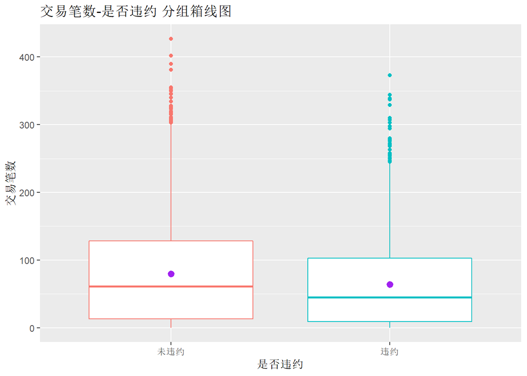

```r
options(warn =-1)
library(ggplot2)
ggplot(data,aes(x=black,y=billnum,color=black)) + geom_boxplot() +
  ggtitle("交易笔数-是否违约 分组箱线图") + labs(x='是否违约',y='交易笔数') +
  scale_x_discrete(labels=c('未违约','违约')) +
  stat_summary(fun=mean,color='purple') + guides(color=F)
```

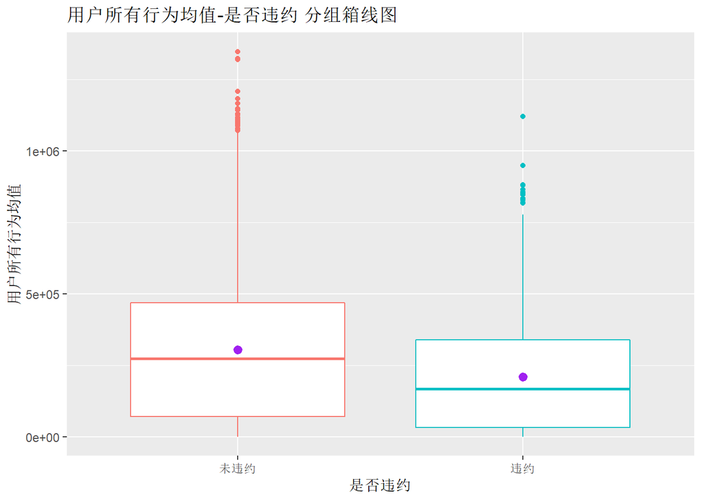

```r
ggplot(data,aes(x=factor(black),y=meanpay,color=black)) + geom_boxplot() +
  ggtitle("用户所有行为均值-是否违约 分组箱线图") + labs(x='是否违约',y='用户所有行为均值') +
  scale_x_discrete(labels=c('未违约','违约')) + stat_summary(fun=mean,color='purple') +
  guides(color=F)
```

### 3.按照7:3划分训练集和测试集，用决策树模型进行建模（提示：划分数据集时设定随机种子=1234；在R中可使用rpart函数，设置为默认参数）；在测试集上进行测试，绘制ROC曲线，计算AUC值

```r
library(rpart)
library(pROC)
#划分数据
set.seed(1234)
index = sample(nrow(data),0.7*nrow(data))
train_set = data[index,]
test_set = data[-index,]
#生成决策树模型
detree = rpart(black~.,data = train_set)
printcp(detree)
```

```
##
## Classification tree:
## rpart(formula = black ~ ., data = train_set)
##
## Variables actually used in tree construction:
## [1] cardnum     creded      debitF      maxpay      meanpay     xindaiR
## [7] zhuanzhangF
##
## Root node error: 1866/5622 = 0.33191
##
## n= 5622
##
##         CP nsplit rel error  xerror     xstd
## 1 0.017149      0   1.00000 1.00000 0.018922
## 2 0.015541      5   0.88639 0.97964 0.018823
## 3 0.010361      6   0.87085 0.95123 0.018677
## 4 0.010000      9   0.83976 0.94695 0.018654
```

由上述信息可知，决策树中实际使用的变量cardnum(银行卡数),creded(借贷比率),debitF(借记类F),maxpay(所有行为最大值),meanpay(所有行为均值),xindaiR(信贷类R),zhuanzhangF(转账类F)。 其中，所有行为指用户被记录的所有交易行为。F指消费频率，R指最近一次消费，指上一次购买的时间到现在的距离

作出ROC曲线并计算AUC：

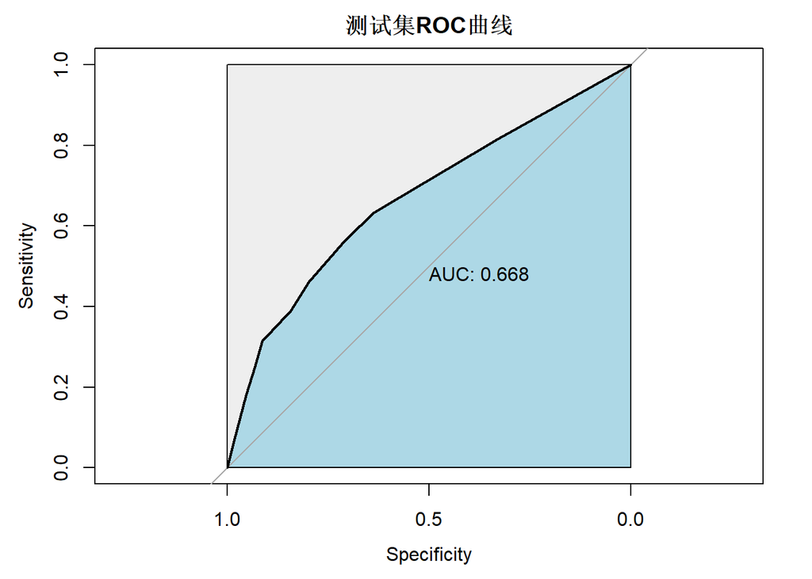

```r
pretree = predict(detree,newdata=test_set)
rcurve = roc(test_set$black,pretree[,2])
plot(rcurve,print.auc=T,main='测试集ROC曲线',auc.polygon=T,auc.polygon.col='lightblue',max.auc.polygon=T)
```

下面计算预测准确率  
首先计算混淆矩阵，0表示未违约，1表示违约

```r
pretree2 = pretree[,2]
pretree2 = as.numeric(pretree2>0.5)
cmatrix = table(test_set$black,pretree2,dnn=c('真实值','预测值'))
#输出混淆矩阵
print(cmatrix)
```

```
##       预测值
## 真实值    0    1
##      0 1456  140
##      1  558  256
```

计算预测准确率

```r
acc = (cmatrix[1,1] + cmatrix[2,2])/sum(cmatrix)
acc_b = cmatrix[2,2]/(cmatrix[2,2]+cmatrix[2,1])
acc_a = cmatrix[1,1]/(cmatrix[1,1]+cmatrix[1,2])
acc_v = c(acc,acc_b,acc_a)
names(acc_v) = c("总体预测准确率","违约用户预测准确率","未违约用户预测准确率")
print(acc_v)
```

```
##       总体预测准确率   违约用户预测准确率 未违约用户预测准确率
##            0.7103734            0.3144963            0.9122807
```

决策树对预测集的预测率约为71.0%, 总体的预测准确率不高。  
决策树对未违约用户的预测准确率较高，为91.2%。对违约用户的预测率较低，只有约31.4%。 可能是因为训练集中违约用户的数量相对较少。需要加强对违约用户特征的识别。  
作出ROC曲线，AUC值为0.668，相对较低，预测结果不够理想。

### 4. 画出决策树的图形，并进行解读

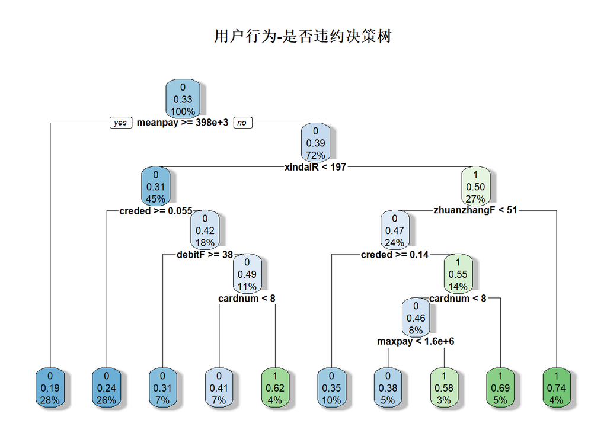

```r
library(rpart.plot)
rpart.plot(detree,branch=1,type=2,fallen.leaves=T,cex=0.7,shadow.col = "gray",main='用户行为-是否违约决策树')
```

决策树中0表示未违约，1表示违约。百分数表示该节点中样本数占总样本数的比例。小数表示该节点中违约的样本数占节点总样本数的比率。叶节点中0或1表示最终分类的结果，内部节点中标出的数据表示将其该节点的子节点剪枝后，该节点作为新的叶节点对应的结果。

该决策树共使用了7个变量特征，与第三问中分析相同。节点的左子树表示满足该节点条件，右子树表示不满足该节点条件。每个节点中0或1表示该节点的标签。

若上述条件仍不满足，则按照决策树的子节点由高到低依次判断，直到到达叶节点。比如，决策树总是偏向将借贷比率高或银行卡数量少的用户划为未违约，将转账频率高的用户划为违约。借贷比率高说明用户经常进行信贷，而银行卡多、转账频率高则可能是用户借贷过多或因无力还款而“拆东墙补西墙”。再比如决策树会将交易平均金额较低而最大交易金额较高的用户划为违约，这可能是因为本身消费能力弱的用户不太可能负担得起高额消费，进行高额消费后会很可能无法还款。节点特征的重要性有高到低依次减弱。

总体上看，决策树更倾向于将消费能力强、信贷习惯好、合理消费的用户划为未违约一类。

由决策树的叶节点可以看出，大部分样本被划分为未违约一类。结合混淆矩阵与箱线图，未违约的用户各特征取值分布的范围更广，且预测为未违约的正确概率很高，预测为违约的正确概率较低，说明该决策树更偏向预测为未违约一类。